# Practical Machine Learning - Course Project

Manuel Fontenla Cadavid

24 de septiembre de 2015

## Summary

The goal of this project is to predict the manner in which an exercise is executed. The data comes from an experiment where 6 participants were asked to perform barbell lifts correctly and incorrectly in 5 different ways, with accelerometers on the belt, forearm, arm and dumbell. All the information collected with them could be used to predict the manner in which the participants did the exercise (the variable “classe”).

The data for this project come from this source: http://groupware.les.inf.puc-rio.br/har

## Libraries and data

The previous steps of the project include install and load the neccesary libraries to build the model:

```r
# Load libraries
#install.packages("caret")
library(caret)
```

Download the data:

```r
# Download data
fileURL <- "https://d396qusza40orc.cloudfront.net/predmachlearn/pml-training.csv"
download.file(fileURL, destfile = "pml-training.csv")
fileURL <- "https://d396qusza40orc.cloudfront.net/predmachlearn/pml-testing.csv"
download.file(fileURL, destfile = "pml-testing.csv")
```

And load the data, with the training set that we use to build our model:

```r
# Load data
# Training set
training <- read.csv("pml-training.csv", row.names = 1)
dim(training)
```

```
## [1] 19622   159
```

And the test set we will use to test our predictions:

```r
# Test set
testing <- read.csv("pml-testing.csv", row.names = 1)
dim(testing)
```

```
## [1]  20 159
```

The training and testing sets contain 159 variables.

## Clean data

At first, we look the initial set of 159 variables:

```r
# Initial variables
str(training)  # 159 variables
```

```
## 'data.frame':    19622 obs. of  159 variables:
##  $ user_name               : Factor w/ 6 levels "adelmo","carlitos",..: 2 2 2 2 2 2 2 2 2 2 ...
##  $ raw_timestamp_part_1    : int  1323084231 1323084231 1323084231 1323084232 1323084232 1323084232 1323084232 1323084232 1323084232 1323084232 ...
##  $ raw_timestamp_part_2    : int  788290 808298 820366 120339 196328 304277 368296 440390 484323 484434 ...
##  $ cvtd_timestamp          : Factor w/ 20 levels "02/12/2011 13:32",..: 9 9 9 9 9 9 9 9 9 9 ...
##  $ new_window              : Factor w/ 2 levels "no","yes": 1 1 1 1 1 1 1 1 1 1 ...
##  $ num_window              : int  11 11 11 12 12 12 12 12 12 12 ...
##  $ roll_belt               : num  1.41 1.41 1.42 1.48 1.48 1.45 1.42 1.42 1.43 1.45 ...
##  $ pitch_belt              : num  8.07 8.07 8.07 8.05 8.07 8.06 8.09 8.13 8.16 8.17 ...
##  $ yaw_belt                : num  -94.4 -94.4 -94.4 -94.4 -94.4 -94.4 -94.4 -94.4 -94.4 -94.4 ...
##  $ total_accel_belt        : int  3 3 3 3 3 3 3 3 3 3 ...
##  $ kurtosis_roll_belt      : Factor w/ 397 levels "","-0.016850",..: 1 1 1 1 1 1 1 1 1 1 ...
##  $ kurtosis_picth_belt     : Factor w/ 317 levels "","-0.021887",..: 1 1 1 1 1 1 1 1 1 1 ...
##  $ kurtosis_yaw_belt       : Factor w/ 2 levels "","#DIV/0!": 1 1 1 1 1 1 1 1 1 1 ...
##  $ skewness_roll_belt      : Factor w/ 395 levels "","-0.003095",..: 1 1 1 1 1 1 1 1 1 1 ...
```

[output cut: 86 more lines]

To start cleaning, we remove all the variables with more than 90% of NA values:

```r
# NA values
variablesNAs <- numeric(ncol(training))
for (i in 1:ncol(training)) {
  sumNAs <- sum(is.na(training[, i]))
  percentNAs <- sumNAs / nrow(training)
  variablesNAs[i] <- percentNAs
}
# Number of variables with > 90% NAs
sum(variablesNAs > 0.9)
```

```
## [1] 67
```

```r
# Remove 67 variables with > 90% NAs
training <- training[, -which(variablesNAs > 0.9)]
testing <- testing[, -which(variablesNAs > 0.9)]
dim(training)  # 92 variables
```

```
## [1] 19622    92
```

```r
dim(testing)  # 92 variables
```

```
## [1] 20 92
```

The next step is discard the variables with many of their values near to zero:

```r
# Near zero values
nzv <- nearZeroVar(training, saveMetrics = TRUE)
# Number of variables with near zero values
sum(nzv$nzv)
```

```
## [1] 34
```

```r
# Remove 34 variables with near zero values
training <- training[, -which(nzv$nzv)]
```

We also check for correlated predictos, but, at this point, there is no one left:

```r
# Correlated predictors
variableClass <- numeric(ncol(training))
for (i in 1:ncol(training)) { variableClass[i] <- class(training[, i]) }
variablesCor <- cor(training[, which(variableClass %in% c("integer", "numeric"))])
# Number of correlated predictors
sum(abs(variablesCor[upper.tri(variablesCor)]) > .999)
```

```
## [1] 0
```

```r
# No correlated predictors
```

The last variables to remove are the variables that collect the username and the time in which the values are collected:

```r
# Remove user_name and time variables
variablesInd <- names(training) %in% c("user_name", "raw_timestamp_part_1",
                       "raw_timestamp_part_2", "cvtd_timestamp", "num_window")
training <- training[, -which(variablesInd)]

# Final number of variables
dim(training)  # 53 variables
```

```
## [1] 19622    53
```

At the end, we finish with a 53 variables, the variable to predict “classe” and 52 predictors that we will use to build our model.

## Data splitting

We split the training data in two data sets that can be used to build and test the model:

```r
# Get indexes of partition
inTrain <- createDataPartition(y = training$classe, p = 0.75, list = FALSE)
# Get partitions
train1 <- training[inTrain, ]
train2 <- training[-inTrain, ]
dim(train1)
```

```
## [1] 14718    53
```

```r
dim(train2)
```

```
## [1] 4904   53
```

## Fit a model

We ran several test, but, at the end, the best model founded is the one built it with the random forest algorithm:

```r
# Control train options
fitControl <- trainControl(method = "none")
# Train model
set.seed(7740)  # set seed for reproducibility
modelFit <- train(classe ~ ., data = train1, method = "rf", trcontrol = fitControl)
modelFit
```

```r
modelFit
```

```
## Random Forest
##
## 14718 samples
##    52 predictor
##     5 classes: 'A', 'B', 'C', 'D', 'E'
##
## No pre-processing
## Resampling: Bootstrapped (25 reps)
## Summary of sample sizes: 14718, 14718, 14718, 14718, 14718, 14718, ...
## Resampling results across tuning parameters:
##
##   mtry  Accuracy   Kappa      Accuracy SD  Kappa SD
##    2    0.9896430  0.9868978  0.001470905  0.001849193
##   27    0.9898318  0.9871374  0.001426801  0.001800057
##   52    0.9821880  0.9774675  0.004138549  0.005231083
##
## Accuracy was used to select the optimal model using  the largest value.
## The final value used for the model was mtry = 27.
```

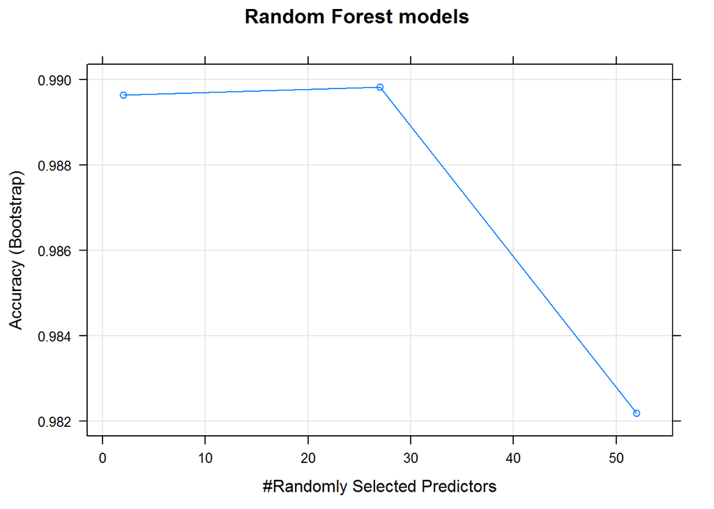

```r
plot(modelFit, main = "Random Forest models")
```

The final model, with mtry = 27, has an accuracy of 0.9898, and we can check the most important variables in it:

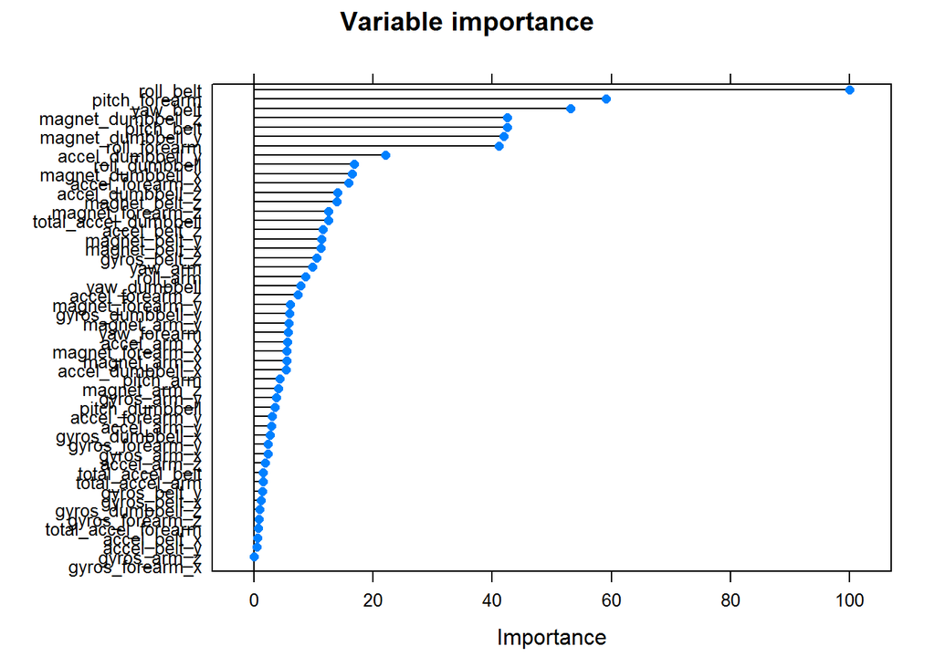

```r
plot(varImp(modelFit), main = "Variable importance")
```

## Prediction

We test our final model against the second part of the data splitted from the training data set:

```r
realvalues <- train2$classe
prediction <- predict(modelFit, newdata = train2)
confusionMatrix(prediction, realvalues)
```

```
## Confusion Matrix and Statistics
##
##           Reference
## Prediction    A    B    C    D    E
##          A 1395    2    0    0    0
##          B    0  947    0    0    0
##          C    0    0  854    3    2
##          D    0    0    1  801    0
##          E    0    0    0    0  899
##
## Overall Statistics
##
##                Accuracy : 0.9984
##                  95% CI : (0.9968, 0.9993)
##     No Information Rate : 0.2845
##     P-Value [Acc > NIR] : < 2.2e-16
##
##                   Kappa : 0.9979
##  Mcnemar's Test P-Value : NA
##
## Statistics by Class:
##
##                      Class: A Class: B Class: C Class: D Class: E
## Sensitivity            1.0000   0.9979   0.9988   0.9963   0.9978
## Specificity            0.9994   1.0000   0.9988   0.9998   1.0000
## Pos Pred Value         0.9986   1.0000   0.9942   0.9988   1.0000
## Neg Pred Value         1.0000   0.9995   0.9998   0.9993   0.9995
## Prevalence             0.2845   0.1935   0.1743   0.1639   0.1837
## Detection Rate         0.2845   0.1931   0.1741   0.1633   0.1833
## Detection Prevalence   0.2849   0.1931   0.1752   0.1635   0.1833
## Balanced Accuracy      0.9997   0.9989   0.9988   0.9980   0.9989
```

The model has an accuracy of 0.9984 against the data splitted from the training data set, with an out of sample error of 0.0016.

## Apply to test data

```r
predictTest <- predict(modelFit, newdata = testing)
predictTest
```

```
##  [1] B A B A A E D B A A B C B A E E A B B B
## Levels: A B C D E
```